### 4월/3주

#### ▶ ▣ 정당지지도 ▣

더불어민주당 35.8%, 국민의힘 33.0%, 녹색정의당 2.4%, 새로운미래 2.4%, 개혁신당 5.5%, 조국혁신당 12.5%, 진보당 0.9%, 그 외 다른 정당 1.8%, 지지하는 정당 없다 4.7%, 잘 모르겠다 0.9%

#### ▶ ▣ 대통령 국정 수행 평가 ▣

잘하고 있다 31.8%, 잘못하고 있다 65.3%, 잘 모르겠다 3.0%

#### ☑ ▣ 尹 국정 기조 변화 기대감 ▣

매우 기대한다 15.7%, 어느 정도 기대한다 22.1%, 별로 기대하지 않는다 17.3%, 전혀 기대하지 않는다 41.4%, 잘 모르겠다 3.5%

#### ☑ ▣ 22대 국회 최우선 과제 ▣

민생 경제 회복 34.1%, 개헌 등 정치개혁 15.3%, 사회 양극화 완화 9.3%, 여야 대립 해소 12.3%, 기후위기/저출생 대응 8.9%, AI 등 미래사회 변화 대비 4.3%, 대통령 국정운영 견제 13.5%, 잘 모르겠다 2.3%

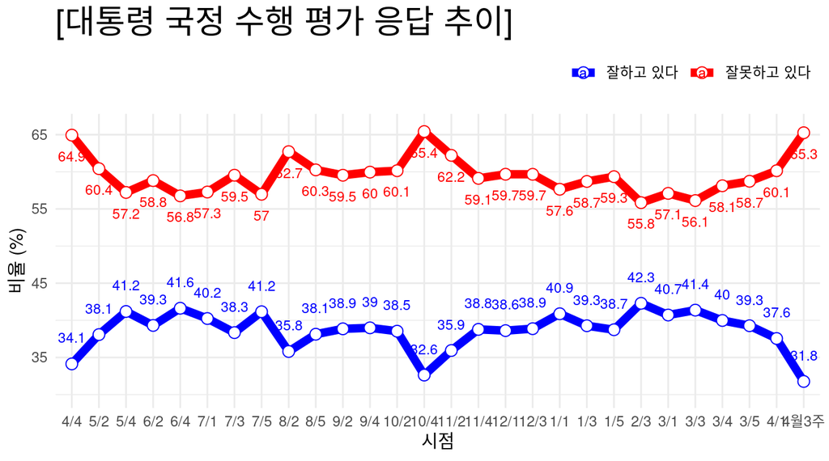

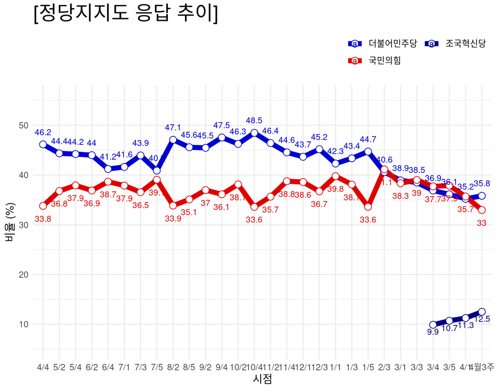

### 추가사항

- [주요질문 / 집단별 세부통계 보기](https://modernity.shinyapps.io/survey_str/) (링크누르시오)

### 참고사항

  전국 만 18세 이상 남녀를 대상으로 ARS 여론조사

  (휴대전화 100% RDD 방식, 성,연령대,지역별 비례할당 후 무작위 추출)를 실시한 결과이며,

  표본수는 2,033(총 통화시도 47,820명, 응답률 4.3%)

  ※ 가중치 부여 방식: [림가중] 성별, 연령별, 지역별 가중값 부여(2024년 3월말 행정안전부 발표 주민등록인구기준)
- [중앙선거여론조사심의위원회](https://nesdc.go.kr/portal/bbs/B0000005/list.do?menuNo=200467)에서 관련사항 확인가능

2024.04.18 (Thu) 15:48 제작

- 연구개발 단계입니다.
- 제공: 감동과 마음의 [조원씨앤아이](http://jowoncni.com/html/index.html)